# Feature Selection

# Load libraries

```r
library(formattable)
library(Boruta)
library(corrplot)
```

# Load manhattan_ints table

```r
manhattan_ints <- read.csv("https://raw.githubusercontent.com/lcao21/GIS3_Final_Project/master/Data/manhattan_ints.csv", stringsAsFactors = FALSE)

# Convert LAND.SQUARE.FEET and GROSS.SQUARE.FEET to numeric
manhattan_ints$LAND.SQUARE.FEET <- gsub(",","",manhattan_ints$LAND.SQUARE.FEET)
manhattan_ints$GROSS.SQUARE.FEET <- gsub(",","",manhattan_ints$GROSS.SQUARE.FEET)
manhattan_ints[,c(10:11)] <- data.frame(apply(manhattan_ints[c(11:12)], 2, as.numeric))

str(manhattan_ints)
```

```
## 'data.frame':    174 obs. of  23 variables:
##  $ ADDRESS                       : chr  "1 SUTTON PLACE, Manhattan" "106 EAST 78TH STREET, Manhattan" "109 WEST 11TH STREET, Manhattan" "11 EAST 129 STREET, Manhattan" ...
##  $ NEIGHBORHOOD                  : chr  "MIDTOWN EAST" "UPPER EAST SIDE (59-79)" "GREENWICH VILLAGE-WEST" "HARLEM-CENTRAL" ...
##  $ BUILDING.CLASS.CATEGORY       : chr  "01 ONE FAMILY DWELLINGS" "01 ONE FAMILY DWELLINGS" "01 ONE FAMILY DWELLINGS" "01 ONE FAMILY DWELLINGS" ...
##  $ BLOCK                         : int  1372 1412 607 1754 576 592 1413 1840 1523 504 ...
##  $ LOT                           : int  26 68 50 8 48 14 120 152 68 29 ...
##  $ ZIP.CODE                      : int  10022 10075 10011 10035 10011 10014 10075 10025 10128 10012 ...
##  $ RESIDENTIAL.UNITS             : int  1 1 1 1 1 3 2 2 1 2 ...
##  $ COMMERCIAL.UNITS              : int  0 1 0 0 0 0 1 0 0 0 ...
##  $ TOTAL.UNITS                   : int  1 2 1 1 1 3 3 2 1 2 ...
##  $ LAND.SQUARE.FEET              : num  5339 4344 4060 2800 8125 ...
##  $ GROSS.SQUARE.FEET             : num  1920 1899 1899 1905 1910 ...
##  $ YEAR.BUILT                    : int  1920 1899 1899 1905 1910 1899 1910 1899 1899 1900 ...
##  $ TAX.CLASS.AT.TIME.OF.SALE     : int  1 1 1 1 1 1 1 1 1 1 ...
##  $ BUILDING.CLASS.AT.TIME.OF.SALE: chr  "A7" "S1" "A4" "A4" ...
##  $ SALE.PRICE                    : num  13000000 7200000 11200000 1550000 19900000 ...
##  $ SALE.DATE                     : chr  "10/8/19" "6/10/19" "5/22/19" "8/22/19" ...
##  $ lat                           : num  40.8 40.8 40.7 40.8 40.7 ...
##  $ lon                           : num  -74 -74 -74 -74 -74 ...
##  $ num_schools                   : int  0 0 2 0 3 0 0 1 0 5 ...
##  $ num_food                      : int  0 0 0 0 1 0 0 1 6 0 ...
##  $ num_parks                     : int  18 14 20 13 5 41 12 27 20 43 ...
##  $ num_subway                    : int  0 1 6 0 5 3 1 2 2 4 ...
##  $ neighborhood_ord              : int  13 15 12 5 12 12 15 8 15 14 ...
```

**Dependent Variable:** SALE.PRICE

**Independent Variables:** num_schools; num_food; num_parks; num_subway; RESIDENTIAL.UNITS; COMMERCIAL.UNITS; LAND.SQUARE.FEET; GROSS.SQUARE.FEET; neighborhood_ord

Now that I have a table with all the variables needed, I have to perform feature selection and will use the Boruta package. The boruta algorithm adds randomness to the dataset by creating shuffled copies of the features (shadow features). Then, it trains a random forest classifier on the extended data set and applies Mean Decrease Accuracy to evaluate the importance of each feature (higher = more important). At each iteration, the algorithm checks whether the feature has a higher Z-score than the max Z-score of its shadow features and removes those features that are deemed highly unimportant. The algorithm stops when all the features are confirmed or rejected.

Next, I implement the boruta algorithm with the independent variables I want.

```r
set.seed(600)
# doTrace = 2 reports more detailed progress of process
boruta <- Boruta(SALE.PRICE ~ num_schools + num_food + num_parks + num_subway + RESIDENTIAL.UNITS + COMMERCIAL.UNITS + LAND.SQUARE.FEET + GROSS.SQUARE.FEET + neighborhood_ord, data = manhattan_ints, doTrace = 2)
boruta
```

```
## Boruta performed 53 iterations in 4.047906 secs.
##  7 attributes confirmed important: LAND.SQUARE.FEET, neighborhood_ord,
## num_food, num_parks, num_schools and 2 more;
##  2 attributes confirmed unimportant: COMMERCIAL.UNITS,
## GROSS.SQUARE.FEET;
```

Here is a visual of the variables by importance in determining sale price:

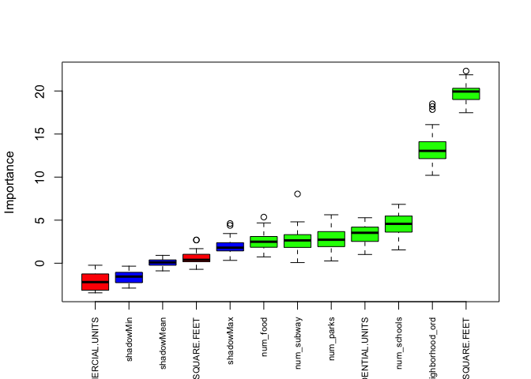

```r
plot(boruta, xlab = "", xaxt = "n")
lz1<-lapply(1:ncol(boruta$ImpHistory),function(i)
boruta$ImpHistory[is.finite(boruta$ImpHistory[,i]),i])
names(lz1) <- colnames(boruta$ImpHistory)
Labels1 <- sort(sapply(lz1,median))
axis(side = 1,las=2,labels = names(Labels1), at = 1:ncol(boruta$ImpHistory), cex.axis = 0.7)
```

```r
getSelectedAttributes(boruta, withTentative = F)
```

```
## [1] "num_schools"       "num_food"          "num_parks"
## [4] "num_subway"        "RESIDENTIAL.UNITS" "LAND.SQUARE.FEET"
## [7] "neighborhood_ord"
```

So the algorithm is telling me:

**Important:**: num_schools, num_food, num_parks, num_subway, RESIDENTIAL.UNITS, LAND.SQUARE.FEET, neighborhood_ord

**Unimportant:** COMMERCIAL.UNITS, GROSS.SQUARE.FEET

I created a data frame of the final results.

```r
boruta_df <- attStats(boruta)
formattable(boruta_df)
```

|  | meanImp | medianImp | minImp | maxImp | normHits | decision |
| --- | --- | --- | --- | --- | --- | --- |
| num_schools | 4.5460742 | 4.5727217 | 1.5462140 | 6.8362993 | 0.96226415 | Confirmed |
| num_food | 2.5600843 | 2.4917348 | 0.7359889 | 5.3551073 | 0.71698113 | Confirmed |
| num_parks | 2.7953069 | 2.7260217 | 0.2634540 | 5.6259558 | 0.69811321 | Confirmed |
| num_subway | 2.5896788 | 2.6505057 | 0.0727896 | 8.0447702 | 0.73584906 | Confirmed |
| RESIDENTIAL.UNITS | 3.3184143 | 3.5324633 | 1.0149558 | 5.2813015 | 0.86792453 | Confirmed |
| COMMERCIAL.UNITS | -2.0534412 | -2.1927787 | -3.4373517 | -0.2344964 | 0.00000000 | Rejected |
| LAND.SQUARE.FEET | 19.7676073 | 19.9385695 | 17.4755618 | 22.3169616 | 1.00000000 | Confirmed |
| GROSS.SQUARE.FEET | 0.7270843 | 0.3893072 | -0.7088997 | 2.7016167 | 0.03773585 | Rejected |
| neighborhood_ord | 13.2224612 | 13.0446294 | 10.2081188 | 18.5055610 | 1.00000000 | Confirmed |

Some models don’t perform well when multicollinearity is present, so I will check for it.

```r
manhattan_indpt <- manhattan_ints[c("num_schools", "num_food", "num_parks", "num_subway", "RESIDENTIAL.UNITS", "LAND.SQUARE.FEET", "neighborhood_ord")]
manhattan_indpt_cor <- cor(manhattan_indpt)
formattable(manhattan_indpt_cor)
```

```
##                   num_schools num_food num_parks num_subway RESIDENTIAL.UNITS
## num_schools       1           -0.0335  0.06981   0.07864    0.1547
## num_food          -0.0335     1        0.1703    -0.1757    0.09656
## num_parks         0.06981     0.1703   1         0.08676    0.2374
## num_subway        0.07864     -0.1757  0.08676   1          -0.1403
## RESIDENTIAL.UNITS 0.1547      0.09656  0.2374    -0.1403    1
## LAND.SQUARE.FEET  -0.123      -0.1507  -0.2719   -0.04941   -0.09654
## neighborhood_ord  -0.3336     -0.3335  -0.3974   0.2608     -0.2691
##                   LAND.SQUARE.FEET neighborhood_ord
## num_schools       -0.123           -0.3336
## num_food          -0.1507          -0.3335
## num_parks         -0.2719          -0.3974
## num_subway        -0.04941         0.2608
## RESIDENTIAL.UNITS -0.09654         -0.2691
## LAND.SQUARE.FEET  1                0.2492
## neighborhood_ord  0.2492           1
```

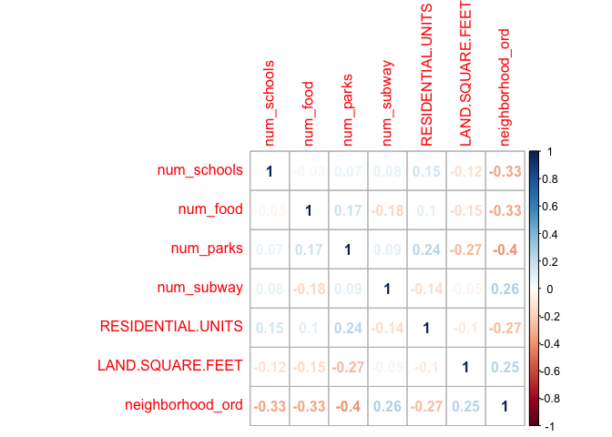

```r
corrplot(manhattan_indpt_cor, method = "number")
```

The typical cutoff for multicollinearity is 0.8, and there luckily aren’t any correlation coefficients even close to that.

Now that I know which features to include, I have to train various models to ultimately pick the best one.